# Sampling Distribution, Central Limit Theorem, and Bootstrapping

Notes and in-class exercises

You can download the .qmd file for this activity here and open in R-studio. The rendered version is posted in the [course website](https://mutasim221b.github.io/Mac-STAT-155-Sp-26/) (Activities tab). I often experiment with the class activities (and see it in live!) and make updates, but I always post the final version before class starts. To be sure you have the most up-to-date copy, please download it once you’ve settled in before class begins.

# Notes

## Learning goals

Let $\beta$ be some *population parameter* and $\hat{\beta}$ be a *sample estimate* of $\beta$. Our goals for the day are to:

- use simulation to solidify our understanding of **sampling distributions** and **standard errors**
- explore and compare two approaches to approximating the sampling distribution of $\hat{\beta}$:
  - Central Limit Theorem (CLT)
  - bootstrapping
- explore the impact of **sample size** on sampling distributions and standard errors

## Readings and videos

Please watch/do the following videos and readings **before** class:

- Reading: Section 6.7 in the [STAT 155 Notes](https://mac-stat.github.io/Stat155Notes/)
- Video 1: [sampling distributions](https://youtu.be/Md0TlOoBW38)
- Video 2: [Central Limit Theorem](https://youtu.be/_Sz0IDI-apk)
- Video 3: [bootstrapping](https://voicethread.com/myvoice/thread/15611638/97563140)

# Warm-Up

Rivers contain small concentrations of mercury which can accumulate in fish. Scientists studied this phenomenon among largemouth bass in the Wacamaw and Lumber rivers of North Carolina.

One goal of this study was to explore the relationship of a fish’s mercury concentration (Concen) with its size, specifically its Length:

$$E(Concen | Length) = \beta_0 + \beta_1 Length$$

To this end, they caught and evaluated 171 fish, and recorded the following:

| variable | meaning |
| --- | --- |
| River | Lumber or Wacamaw |
| Station | Station number where the fish was caught (0, 1, …, 15) |
| Length | Fish’s length (in centimeters) |
| Weight | Fish’s weight (in grams) |
| Concen | Fish’s mercury concentration (in parts per million; ppm) |

```r
# Load the data & packages
library(tidyverse)
fish <- read_csv("https://Mac-STAT.github.io/data/Mercury.csv")
```

Plot and model the relationship of mercury concentration with length:

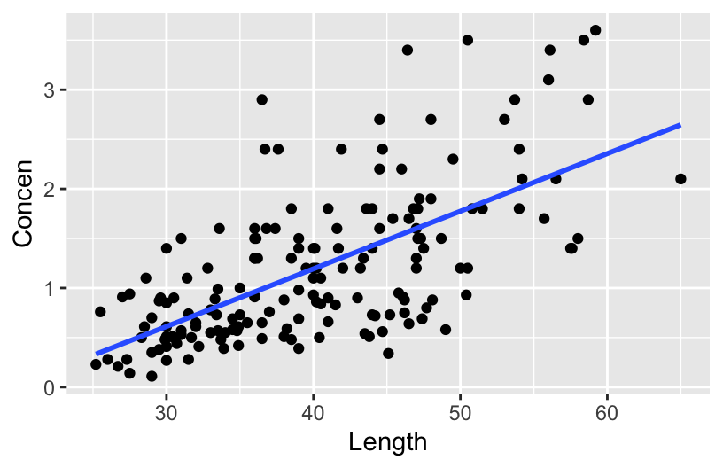

```r
fish %>%
  ggplot(aes(y = Concen, x = Length)) +
  geom_point() +
  geom_smooth(method = "lm", se = FALSE)
```

```r
fish_model <- lm(Concen ~ Length, data = fish)
coef(summary(fish_model))
##                Estimate  Std. Error   t value     Pr(>|t|)
## (Intercept) -1.13164542 0.213614796 -5.297598 3.617750e-07
## Length       0.05812749 0.005227593 11.119359 6.641225e-22
```

1. In the summary table, is the `Length` coefficient 0.058 the *population parameter* $\beta_1$ or a *sample estimate* $\hat{\beta}_1$?

> Your response here

Since we don’t know $\beta_1$, we *can’t* know the exact error in $\hat{\beta}_1$! This is where **sampling distributions** come in.

They describe how estimates $\hat{\beta}_1$ might vary from sample to sample, thus how far these estimates might fall from $\beta_1$:

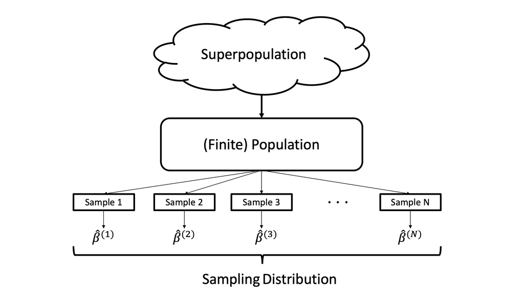

For each of the concepts in the diagram above (Superpopulation, Finite Population, Sample), these represent for this specific data example:

> Superpopulation: The true underlying process that governs the relationship between mercury concentration and length of fish, for every fish that has ever existed and ever will exist in these two rivers!

> Finite Population: At the time the data was collected, the true observed relationship between mercury concentration and length of fish, for all fish in the two rivers *at that time*.

> Sample: In our data, the observed/estimated relationship between mercury concentration and length of fish (this is $\hat{\beta}_1$!).

In the previous activity, each student took *1* sample of 10 observations.

This gave us a quick sense of how these estimates could vary from sample to sample.

When trying to understand/approximate our sampling distribution, there are two main approaches we can take:

1. When our sample size n is “large enough”, we might approximate the sampling distribution using the CLT:

$$\hat{\beta}_1 \sim N(\beta_1, \text{standard error}^2)$$

The standard error in the CLT is approximated from our *sample* via some formula $c / \sqrt{n}$ where “c” is complicated.

2. Obtain and interpret this standard error from the model summary table:

```r
coef(summary(fish_model))
##                Estimate  Std. Error   t value     Pr(>|t|)
## (Intercept) -1.13164542 0.213614796 -5.297598 3.617750e-07
## Length       0.05812749 0.005227593 11.119359 6.641225e-22
```

2. Our *second* option is something called *bootstrapping*. It turns out that we can actually *resample* from our observed data, to approximate the sampling distribution of our estimate! If it feels somewhat magical to you that this works out, that’s a very reasonable feeling.

The saying “*to pull oneself up by the bootstraps*” is often attributed to Rudolf Erich Raspe’s 1781 *The Surprising Adventures of Baron Munchausen* in which the character pulls himself out of a swamp by his hair (not bootstraps). In short, it means to get something from nothing, through your own effort:

[figure not shown]

In this spirit, statistical bootstrapping **doesn’t make any probability model assumptions**. It uses only the information from our one sample to approximate standard errors.